# ECON5821-Presentation

re7ird

2023-05-07

## ECON5811 Final-Presentation

In this presentation, I will introduce my method and show you the results of the performance on training and validation data.

The code below will be different from the version I provide to do multiple tests. The method is the same. In this presentation, I will only show the simple version.

```r
load(url("https://github.com/zhentaoshi/Econ5821/raw/main/data_example/dataset_inf.Rdata"))

library(tidyverse)
library(glmnet)
set.seed(10)
n=2
```

Prepare dataset:

I want to use the data $x_t$ to predict $y_{t+1}$. I merged cpi data and X, then add a new column y. y is the cpi value of next month, which is the value to be predicted. This assumes that the economic data of this month will affect the cpi data next month. The assumption is not very solid.

```r
#Lag=1:
data_1=merge(cpi,X,by="month",all = T)
data_1=data_1 |> mutate(y=lead(CPI))
```

Dataset x contains 152 variables. These variables are highly correlated. The first method that occurs to me is dimension reduction. The PCA is a good method. I use data from all 168 observations to train the PCA model.

```r
data_1=merge(cpi,X,by="month",all = T)
data_1=data_1 |> mutate(y=lead(CPI)) |> filter(is.na(y)==F)


#Train the PCA model
pca_data=data_1 |> select(!c("month","y","CPI"))
PCA=princomp(pca_data)
```

```r
summary(PCA)
```

```
## Importance of components:
##                             Comp.1      Comp.2      Comp.3      Comp.4
## Standard deviation     269.2907720 143.3479542 139.0547754 82.68681162
## Proportion of Variance   0.5450926   0.1544580   0.1453447  0.05139251
## Cumulative Proportion    0.5450926   0.6995506   0.8448953  0.89628783
##                             Comp.5      Comp.6      Comp.7      Comp.8
## Standard deviation     61.56295469 40.97913195 38.52071357 37.24170572
## Proportion of Variance  0.02848828  0.01262272  0.01115362  0.01042525
## Cumulative Proportion   0.92477612  0.93739884  0.94855246  0.95897771
##                              Comp.9      Comp.10      Comp.11      Comp.12
## Standard deviation     31.573500857 29.754044392 25.197933455 20.602190848
## Proportion of Variance  0.007493295  0.006654561  0.004772624  0.003190466
## Cumulative Proportion   0.966471006  0.973125566  0.977898190  0.981088657
##                             Comp.13      Comp.14      Comp.15    Comp.16
## Standard deviation     18.913198476 17.921067078 16.512551811 15.4944705
## Proportion of Variance  0.002688793  0.002414099  0.002049537  0.0018046
## Cumulative Proportion   0.983777449  0.986191549  0.988241086  0.9900457
##                             Comp.17     Comp.18      Comp.19      Comp.20
## Standard deviation     13.105288521 12.17737217 11.663852541 10.641007035
## Proportion of Variance  0.001290983  0.00111464  0.001022613  0.000851124
## Cumulative Proportion   0.991336668  0.99245131  0.993473921  0.994325045
##                             Comp.21      Comp.22     Comp.23      Comp.24
## Standard deviation     1.022984e+01 8.8132236787 8.036618300 7.9240693937
## Proportion of Variance 7.866194e-04 0.0005838442 0.000485483 0.0004719803
## Cumulative Proportion  9.951117e-01 0.9956955087 0.996180992 0.9966529721
##                             Comp.25      Comp.26    Comp.27      Comp.28
## Standard deviation     7.5841541299 7.0439160436 6.60596794 5.8760495755
## Proportion of Variance 0.0004323562 0.0003729544 0.00032802 0.0002595364
## Cumulative Proportion  0.9970853283 0.9974582827 0.99778630 0.9980458391
##                            Comp.29      Comp.30      Comp.31    Comp.32
## Standard deviation     5.760229220 5.5749678500 5.0440400005 4.96652840
## Proportion of Variance 0.000249406 0.0002336211 0.0001912425 0.00018541
## Cumulative Proportion  0.998295245 0.9985288662 0.9987201087 0.99890552
##                             Comp.33      Comp.34      Comp.35      Comp.36
## Standard deviation     4.6335941317 3.8919023498 3.8032540253 3.475639e+00
## Proportion of Variance 0.0001613851 0.0001138548 0.0001087272 9.080229e-05
## Cumulative Proportion  0.9990669038 0.9991807586 0.9992894857 9.993803e-01
##                             Comp.37      Comp.38      Comp.39      Comp.40
## Standard deviation     3.3124719997 2.722856e+00 2.654890e+00 2.575969e+00
## Proportion of Variance 0.0000824768 5.572844e-05 5.298103e-05 4.987797e-05
```

[output cut: 98 more lines]

```
## Standard deviation     1.864892e-03 1.771448e-03 1.576157e-03 1.205564e-03
## Proportion of Variance 2.614177e-11 2.358761e-11 1.867352e-11 1.092465e-11
## Cumulative Proportion  1.000000e+00 1.000000e+00 1.000000e+00 1.000000e+00
##                            Comp.141     Comp.142     Comp.143     Comp.144
## Standard deviation     8.969493e-04 6.665375e-04 4.897905e-04 3.517424e-04
## Proportion of Variance 6.047323e-12 3.339463e-12 1.803217e-12 9.299867e-13
## Cumulative Proportion  1.000000e+00 1.000000e+00 1.000000e+00 1.000000e+00
##                            Comp.145     Comp.146     Comp.147     Comp.148
## Standard deviation     2.850328e-04 1.876568e-04 1.446396e-04 3.956858e-05
## Proportion of Variance 6.106848e-13 2.647011e-13 1.572540e-13 1.176870e-14
## Cumulative Proportion  1.000000e+00 1.000000e+00 1.000000e+00 1.000000e+00
##                            Comp.149     Comp.150 Comp.151
## Standard deviation     5.605111e-09 3.245283e-09        0
## Proportion of Variance 2.361543e-22 7.916486e-23        0
## Cumulative Proportion  1.000000e+00 1.000000e+00        1
```

We can see that the first 8 dimensions can explain more than 95% of the variance. I assume that all other dimensions are noises and the first 8 components contain all the information I need. This assumption is not very solid either.

The data in x do not contain all the data I need to predict y. I assume that the conditional expectation $E(y_{t+1}|X_t)$ is stable and other factors do not vary much in one year(12 months). For convenience, I use 12 months of data to train the regression and one month to do the testing(rolling windows).

$$E(y_{t+1}|X_t) =\alpha+ PC_t \beta \quad t \in [i,i+12] \quad \\
y_{t+1} =\alpha+ PC_t \beta +\sigma$$

for any int $i≥1$.

$\beta$ is the coefficient matrix and $\alpha$ is the intercept.

I choose Lasso Regression to do the prediction.

First, I use the data from 12 months to train the lasso regression to fit the parameter.

Then I calculate the PCs for next month and use Lasso Regression to predict inflation.

The code below is just for demonstration.

```r
y_train=data_1[1:12,"y"]
y_test=data_1[13,"y"]
x_train=data_1[1:12,] |> select(!c("month","y","CPI"))
x_test=data_1[13,] |> select(!c("month","y","CPI"))


#collect 8 Principal Components and train the lasso regression.
PC=predict(PCA,newdata = x_train)[,1:8]

#Calculate scores for testing
PC_test=predict(PCA,newdata = x_test)[,1:8]

#Train the Lasso Regression: Find Lambda
cv_model <- cv.glmnet(PC, y_train, alpha = 1,nfolds = 3)
best_lambda <- cv_model$lambda.min

#display optimal lambda value
best_lambda
```

```
## [1] 0.3043395
```

```r
#view coefficients of best model
pca_lasso <- glmnet(PC, y_train, alpha = 1, lambda =best_lambda)
coef(pca_lasso)
```

```
## 9 x 1 sparse Matrix of class "dgCMatrix"
##                        s0
## (Intercept)  1.012641e+02
## Comp.1       3.663155e-05
## Comp.2       .
## Comp.3       .
## Comp.4       .
## Comp.5       .
## Comp.6       1.815714e-03
## Comp.7       1.629819e-02
## Comp.8      -5.195176e-03
```

```r
summary(pca_lasso)
```

```
##           Length Class     Mode
## a0        1      -none-    numeric
## beta      8      dgCMatrix S4
## df        1      -none-    numeric
## dim       2      -none-    numeric
## lambda    1      -none-    numeric
## dev.ratio 1      -none-    numeric
## nulldev   1      -none-    numeric
## npasses   1      -none-    numeric
## jerr      1      -none-    numeric
## offset    1      -none-    logical
## call      5      -none-    call
## nobs      1      -none-    numeric
```

```r
#make a prediction for the response value of a new observation
yp=predict(pca_lasso, s = best_lambda, newx = PC_test)[1,1]

yp
```

```
##       s1
## 101.7285
```

```r
y_test
```

```
## [1] 102.1
```

I think the inflation of one month will affect the next month so I introduced an alternative model that added the CPI of the month into the Lasso regression.

```r
data=data_1
dim=8

y_train=data[1:12,"y"]
y_test=data[13,"y"]
x_train=data[1:12,] |> select(!c("month","y","CPI"))
x_train_cpi=data[1:12,"CPI"]
x_test=data[13,] |> select(!c("month","y","CPI"))
x_test_cpi=data[13,"CPI"]


#collect 8 Principal Components and train the lasso regression.
PC=predict(PCA,newdata = x_train)[,1:dim]
PCs=cbind(PC,x_train_cpi)

#Calculate scores for testing
PC_test=predict(PCA,newdata = x_test)[,1:dim]
PC_test2=append(PC_test,x_test_cpi)

#find lambda
cv_model <- cv.glmnet(PCs, y_train, alpha = 1,nfolds = 3)
best_lambda <- cv_model$lambda.min

#display optimal lambda value
best_lambda
```

```
## [1] 0.03446237
```

```r
#view coefficients of best model

pca_lasso2 <- glmnet(PCs, y_train, alpha = 1, lambda =best_lambda)
coef(pca_lasso2)
```

```
## 10 x 1 sparse Matrix of class "dgCMatrix"
##                        s0
## (Intercept) 26.3230098884
## Comp.1       0.0006495455
## Comp.2       0.0000630481
## Comp.3      -0.0011913453
## Comp.4       .
## Comp.5       0.0035970830
## Comp.6       .
## Comp.7       0.0029676058
## Comp.8      -0.0073717333
## x_train_cpi  0.7413640115
```

```r
summary(pca_lasso2)
```

```
##           Length Class     Mode
## a0        1      -none-    numeric
## beta      9      dgCMatrix S4
## df        1      -none-    numeric
## dim       2      -none-    numeric
## lambda    1      -none-    numeric
## dev.ratio 1      -none-    numeric
## nulldev   1      -none-    numeric
## npasses   1      -none-    numeric
## jerr      1      -none-    numeric
## offset    1      -none-    logical
## call      5      -none-    call
## nobs      1      -none-    numeric
```

```r
#make a prediction for the response value of a new observation

yp=predict(pca_lasso2, s = best_lambda, newx = PC_test2)[1,1]


yp
```

```
##       s1
## 102.8934
```

```r
y_test
```

```
## [1] 102.1
```

And then I did multiple tests of different parameters.

Lag=1 means I use $X_t$ to predict $y_{t+1}$. I also tried Lag=2 and Lag=3(a quarter) .

A more general model:
$$E(y_{t+Lag}|X_t) =\alpha+ PC_t \beta +CPI_t *\beta \quad t \in
[i,i+window\ size] \quad \\
y_{t+Lag} =\alpha+ PC_t \beta + CPI_t * \beta +\sigma$$

I tried PCA with 8, 9, and 10 dimensions. Combining all these differences, I tested 18 models in total.

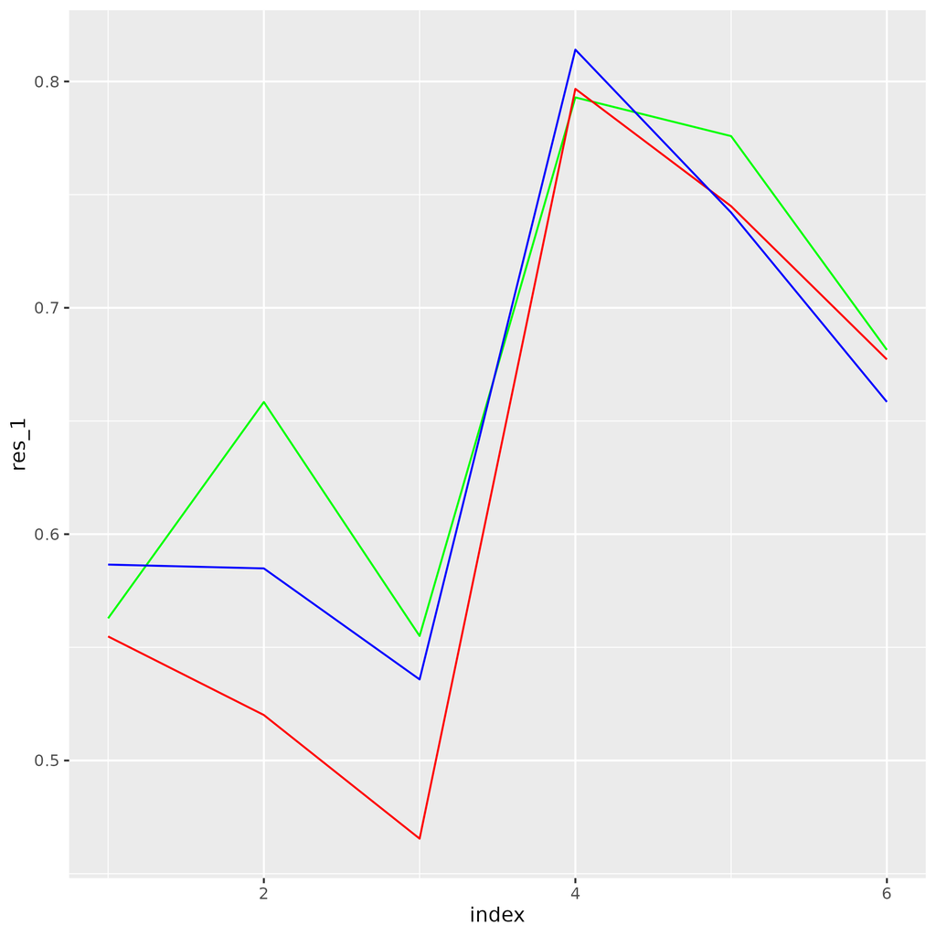

window size = 12 (one year)

green: dim = 8, red: dim = 9, blue: dim=10

Model1: Lag=1,no CPI

Model2: Lag=2,no CPI

Model3: Lag=3,no CPI

Model4: Lag=1,with CPI

Model5: Lag=2,with CPI

Model6: Lag=3,with CPI.

The model with CPI as an independent variable is better than without it.

Why do I add CPI as an independent variable in Lasso Regression but not in PCA?

The CPI of the former month is so important and if I put it in PCA with other 152 variables then it will dilute the weight of the variable. The results will be worse.

And then we found that the window length is too small(12 months) and we have more than 8 independent variables in Lasso. The Lasso estimation might not be very well. We tried different window lengths and we found that 12 months isn’t the best solution for the model. 60 months for training lasso is better.

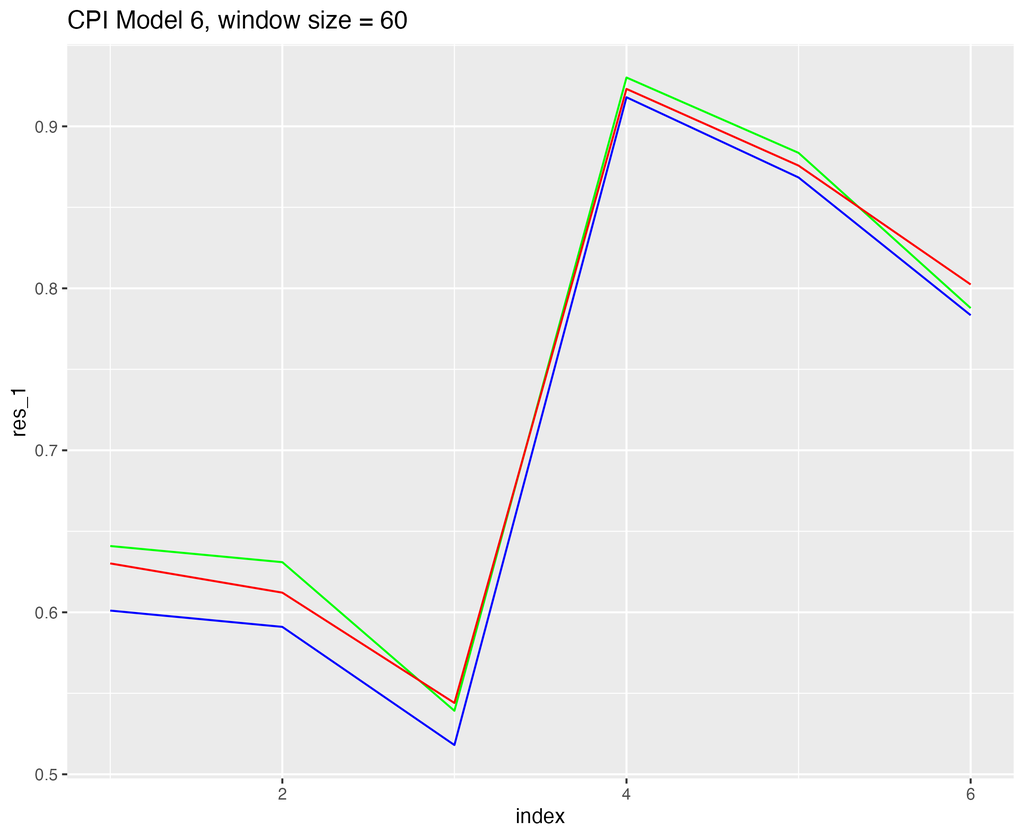

Window size = 60 months.

We can see that after we add more samples into the Lasso, the difference between PCA dimensions becomes small. I think this is because as the sample size goes up, the Lasso regression can penalize the noises correctly and thus reduce the effect of noises.

Now we want to find the best window size. We knew that if the window size is too small, then the Lasso models won’t fit well. If the window size is too large, it will also lower the R-square.

We wrote another file that only try Lag=1, with CPI, dim=8 but different sample size. Here are the results:

See *CPI_model6_find_window_size.R*

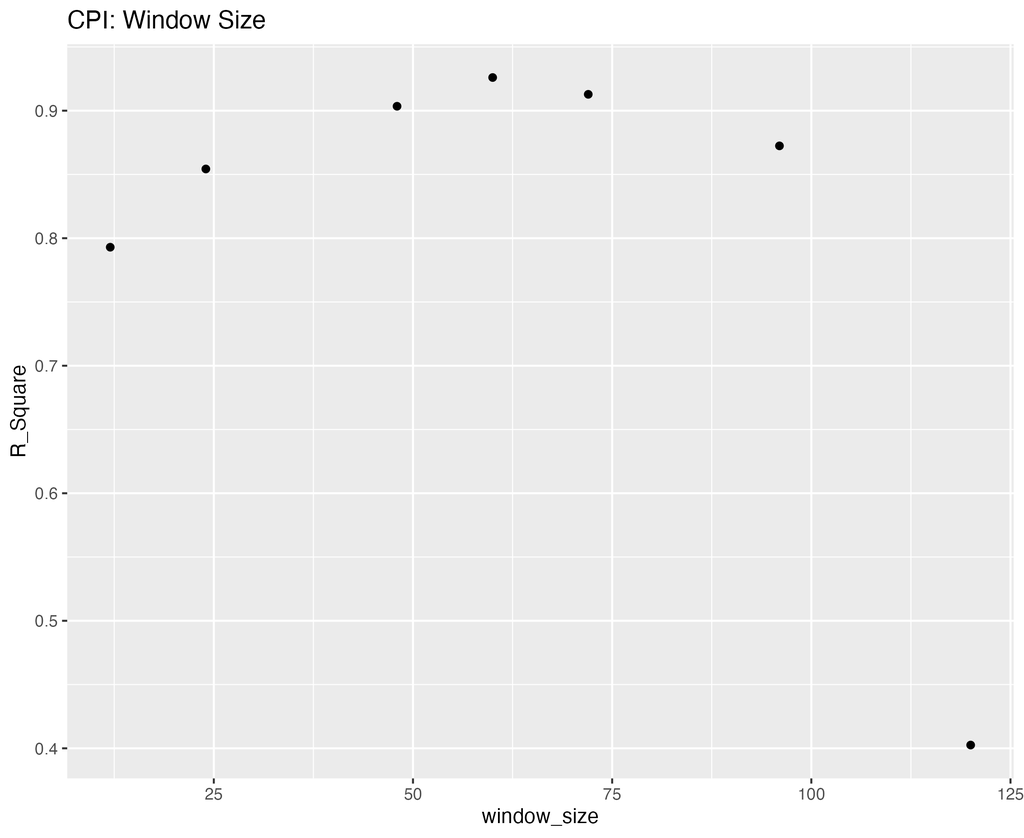

The best model for CPI:

Lag=1, with CPI, dim = 8, window size = 60

Best R-Square = 0.9292863

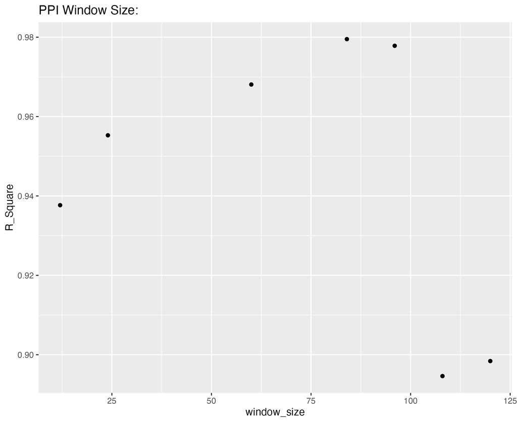

The best model for PPI:

Lag=1, with CPI, dim = 8 window size = 84

The best R-Square: 0.9795128